# Lab 0: Distribuciones de probabilidad

Javier Fernández López

7/3/2022

R es un entorno y lenguaje de programación con un enfoque al análisis estadístico. Es muy útil en nuestro ámbito de estudio porque nos permite combinar potentes herramientas de análisis estadístico con la generación de gráficos y el trabajo con cartografía como si fuera un sistemas de información geográfica (GIS). Las diferentes utilidades o herramientas de R (functions) se organizan en bibliotecas o paquetes (libraries o packages). Algunos de ellos vienen preinstalados con R. Otros deben descargarse e instalarse, y las deberemos cargar en la sesión de R cada vez que las queramos usar. Una de las mayores ventajas de R es que, al ser un lenguaje de código abierto, cualquiera puede contribuir al elenco de herramientas disponibles para el lenguaje a través del desarrollo de paquetes o bibliotecas.  
En esta primera práctica nos familiarizaremos con las funciones relacionadas con las diferentes distribuciones de probabilidad que hemos estudiado en clase.

# Introducción

Empezaremos por consultar la ayuda `help()` que R nos ofrece sobre las distribuciones de probabilidad incluidas en el paquete `stats`.

```r
help(Distributions)
```

| Distributions | R Documentation |
| --- | --- |

## Distributions in the stats package

### Description

Density, cumulative distribution function, quantile function and random variate generation for many standard probability distributions are available in the stats package.

### Details

The functions for the density/mass function, cumulative distribution function, quantile function and random variate generation are named in the form `dxxx`, `pxxx`, `qxxx` and `rxxx` respectively.

For the beta distribution see `dbeta`.

For the binomial (including Bernoulli) distribution see `dbinom`.

For the Cauchy distribution see `dcauchy`.

For the chi-squared distribution see `dchisq`.

For the exponential distribution see `dexp`.

For the F distribution see `df`.

For the gamma distribution see `dgamma`.

For the geometric distribution see `dgeom`. (This is also a special case of the negative binomial.)

For the hypergeometric distribution see `dhyper`.

For the log-normal distribution see `dlnorm`.

For the multinomial distribution see `dmultinom`.

For the negative binomial distribution see `dnbinom`.

For the normal distribution see `dnorm`.

For the Poisson distribution see `dpois`.

For the Student’s t distribution see `dt`.

For the uniform distribution see `dunif`.

For the Weibull distribution see `dweibull`.

For less common distributions of test statistics see `pbirthday`, `dsignrank`, `ptukey` and `dwilcox` (and see the ‘See Also’ section of `cor.test`).

### See Also

`RNG` about random number generation in **R**.

The CRAN task view on distributions, https://CRAN.R-project.org/view=Distributions, mentioning several CRAN packages for additional distributions.

Como podemos observar, R nos permite trabajar con todas las distribuciones que hemos comentado previamente: binomial, de Poisson, normal, uniforme, beta y gamma. A lo largo de la práctica exploraremos dos distribuciones, una para variables aleatorias discretas y otra para continuas y a continuación propondremos una serie de ejercicios.

# Variable aleatoria discreta: distribución binomial

Para refrescar conceptos, comentaremos que la distribución binomial sirve para contar el número de éxitos dado un número de ensayos *n* y una probabilidad de éxito *p*.
$$\begin{equation}
\tag{Eq 1}\label{eq1}
X \sim bin(n, p)
\end{equation}$$
Empezaremos por echar un vistazo al manual (ayuda) de esta distribución. Para ello escribiremos `help(dbinom)`. Como vemos, podemos trabajar con 4 funciones relacionadas con la distribución binomial:

1. `dbinom()` nos indica la densidad de probabilidad de una distribución binomial dada y nos sirve para calcular la probabilidad de que nuestra variable aleatoria X alcance cierto valor P(X = x).
2. `pbinom()` nos indica la función de distribución y nos sirve para calcular la probabilidad de que nuestra variable aleatoria X sea menor o igual que cierto valor P(X $\leq$ x).
3. `qbinom()` nos indica la función de cuantiles.
4. `rbinom()` sirve para generar números aleatorios obtenidos a partir de una distribución binomial dada.

Trabajaremos con el ejemplo que hemos comentado en clase. Nuestro ensayo será tirar una moneda al aire. Repetiremos este ensayo 100 veces. Asumimos que la moneda no está trucada, por lo que la probabilidad de obtener una cara (probabilidad de éxito) es del 50% (*p*=0.5).  
Para calcular la probabilidad de que en 100 tiradas, obtengamos exáctamente 50 caras, podemos usar:

```r
dbinom(50,100,0.5)
```

```
## [1] 0.07958924
```

Esto nos indica que tendríamos una probabilidad de casi el 8% de que al tirar 100 veces una moneda, obtuviésemos 50 caras. Podemos comprobar si en la [aplicación web de Mat Bognar](https://homepage.divms.uiowa.edu/~mbognar/applets/bin.html) obtenemos el mismo resultado. Veamos ahora brevemente un poco de la sintaxis de la función `dbinom`:

- `50` es el número de éxitos del cual queremos saber su probabilidad (número de caras).
- `100` es el número de ensayos de nuestro experimento (número de lanzamientos de la moneda).
- `0.5` es la probabilidad de obtener un éxito (probabilidad de obtener una cara).

Ahora estamos interesados en saber la probabilidad de que, al tirar 100 veces una moneda, obtengamos 50 caras o menos:

```r
pbinom(50,100,0.5)
```

```
## [1] 0.5397946
```

Vemos que tendríamos aproximadamente un 54% de probabilidades de obtener 50 caras o menos en nuestro experimento. Igualmente, podemos combrobar este experimiento en la [aplicación web](https://homepage.divms.uiowa.edu/~mbognar/applets/bin.html).

Por último, podemos utilizar R para generar números aleatorios obtenidos a partir de una distribución binomial $X \sim bin(100, 0.5)$. Esto sería a repetir muchas veces el experimento “lanzar 100 veces una moneda” y contar el número de caras. Como sabemos que la moneda no está trucada y que por tanto $p = 0.5$, en la mayoría de los experimentos, obtendremos un número de caras cercano a 50 (un poco mayor o un poco menor). Veámoslo con un ejemplo usando `rbinom`:

```r
rbinom(1,100,0.5)
```

```
## [1] 52
```

Como vemos, obtenemos un número de caras (éxitos) cercano a 50. Para repetir 10 veces este experimento (lanzar 100 veces una moneda al aire y apuntar el número de caras), podemos indicarlo en el primer argumento de la función:

```r
rbinom(10,100,0.5)
```

```
##  [1] 48 50 56 57 46 49 48 53 50 57
```

Si repetimos muchas veces más el mismo experimento (>10000) podremos organizar los resultados en un histograma y observar con qué frecuencia obtenemos cada uno de los resultados.

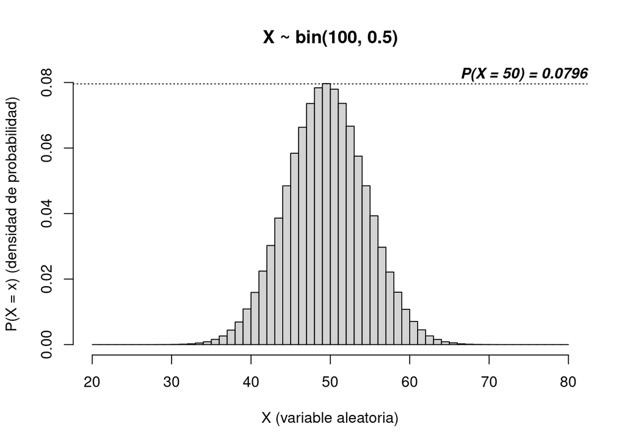

```r
hist(rbinom(1000000,100,0.5), breaks = 20:80, freq = FALSE,
           main = "X ~ bin(100, 0.5)", xlab = "X (variable aleatoria)",
           ylab = "P(X = x) (densidad de probabilidad)")

abline(h=dbinom(50,100,0.5), lty = 3)
mtext("P(X = 50) = 0.0796", adj = 1, line = -0.5, font = 4)
```

# Variable aleatoria continua: distribución normal

Como ya sabemos, la distribución normal o Gausiana consta de dos parámetros, la media $\mu$ que en este caso coincide con la moda y la mediana y corresponde al centro de la “campana” que dibuja esta distribución, y la desviación típica $\sigma$ que es una medida de la dispersión de los datos y correspondería a la “anchura” de la la “campana.
$$\begin{equation}
\tag{Eq 2}\label{eq2}
X \sim N(\mu, \sigma)
\end{equation}$$

Una variable aleatoria continua que típicamente sigue una distribución normal es la estatura del ser humano. Asumimos que la estatura de la población española sigue una distribución normal $X \sim N(169, 7)$ (169 centímetros de media, con una desviación típica de 7 centímetros). Utilizando la función `dnorm()` de forma similar a como lo hemos hecho en el ejemplo de la distribución binomial, podemos calcular la probabilidad de que al seleccionar una persona al azar su estatura sea de 150 centímetros.

```r
dnorm(150,169,7)
```

```
## [1] 0.001432231
```

Como vemos, hay una probabilidad muy baja (0.001) de que al seleccionar una persona al azar mida 150 centímetros. Veamos ahora que probabilidad hay de que la persona seleccionada mida 169 centímetros, que es la media de nuestra distribución.

```r
dnorm(169,169,7)
```

```
## [1] 0.05699175
```

Vemos ahora que esta probabilidad es bastante mayor, llegando hasta el 5%. Podemos ahora preguntarnos que probabilidad hay de que al seleccionar un individuo de esta población, este mida menos de 169 centímetros.

```r
pnorm(169,169,7)
```

```
## [1] 0.5
```

Como ya habríamos imaginado, al tratarse de la media, la propabilidad de obtener un individuo por debajo de 169 centímetros es del 50%. Realizaremos ahora un gráfico para representar la probabilidad de que una persona al azar mida más de 175 centímetros.

```r
1 - pnorm(175, 169,7)
```

```
## [1] 0.195683
```

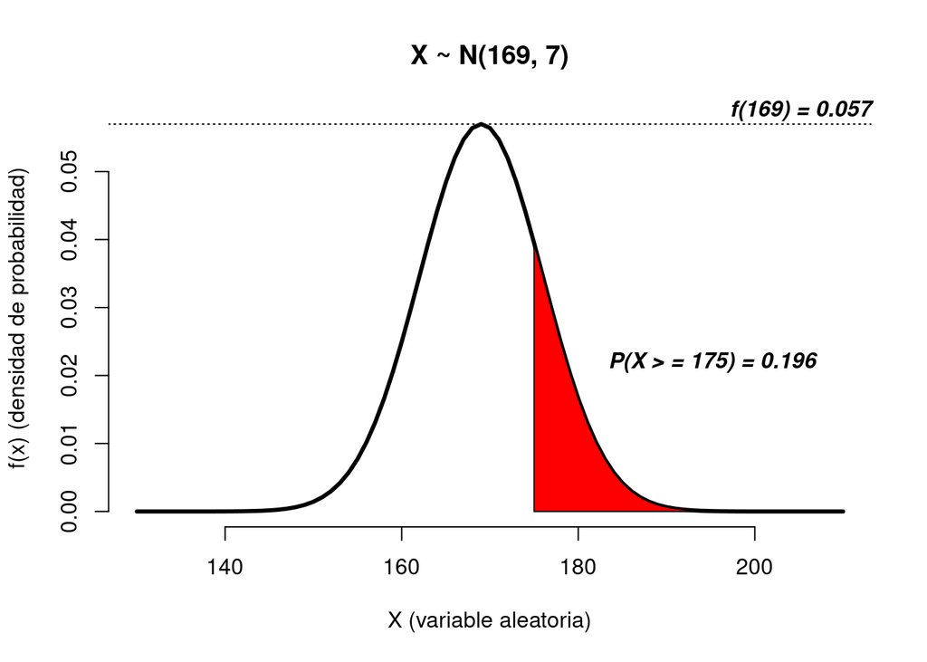

```r
x <- 130:210
y <- dnorm(x,169,7)
plot(x,y, type = "l", lwd = 3, main = "X ~ N(169, 7)", axes = F,
     xlab = "X (variable aleatoria)",
     ylab = "f(x) (densidad de probabilidad)")
axis(side=1); axis(side=2)
abline(h=dnorm(169,169,7), lty = 3)
mtext("f(169) = 0.057", adj = 1, line = -0.5, font = 4)

polygon(c(x[x>=175], max(x), 175), c(y[x>=175], 0, 0), col="red")

mtext("P(X > = 175) = 0.196", adj = 0.90, line = -10, font = 4)
```

Por último, al igual que en el ejemplo anterior, podemos utilizar la función `rnorm()` para generar números aleatorios a partir de de nuestra distribución normal.

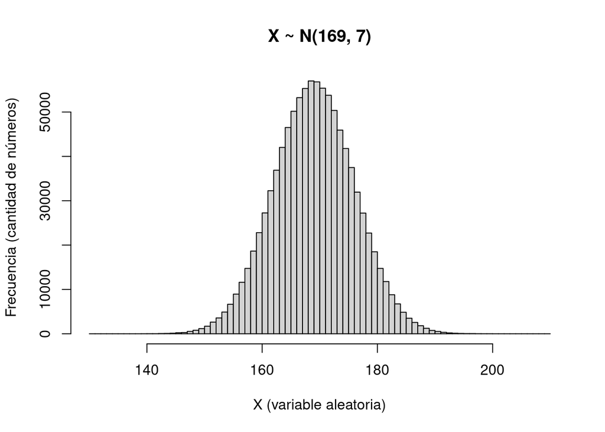

```r
hist(rnorm(1000000,169,7), breaks = 130:210, freq = TRUE,
           main = "X ~ N(169, 7)", xlab = "X (variable aleatoria)",
           ylab = "Frecuencia (cantidad de números)")
```

# Ejercicios

1. En un parque nacional se pueden encontrar de media 4 individuos de ciervo rojo (*Cervus elaphus*) en cada celda de una cuadrícula de 1 km de lado. ¿Cuál será la probabilidad de encontrar 7 ciervos en una celda?
2. La probabilidad de detectar un gallipato (*Pleurodeles waltl*) en su hábitat natural es del 30%. Si en una charca hay 50 gallipatos, ¿qué probabilidad habrá de detectar al menos 10 gallipatos?